# The Athletic Media Company

Luis Noguera

11/27/2019

[figure not shown]

# **Growth Marketing Analysis**

The analysis focused on identifying article’s effectiveness to drive installs and conversions, to help the performance team optimize high value content that helps acquire more users. Second, iPhone and Android devices conversions were compared to prioritize product development. Third, days from install to conversion cohorts were analyzed to build retargeting campaigns based on past user behavior and conversion. Finally, a decision tree data model constructed to understand the conversion likelihood based on multiple variables.

*Browse through each of the 6 sections to find the code, comment insights and graphs.*

**Menu**

## 1.Data Pre-processing

### **Importing Data and R Libraries**

Three data sets have been imported at the same time and useful libraries have been loaded.

```r
# Set Working Directory
setwd('/Users/luisnoguera/Desktop/The-Athletic-Assessment/The-Athletic-Media-Company')

# Importing files into R all at once
temp = list.files(pattern="*.csv")
list2env(
  lapply(setNames(temp, make.names(gsub("*.csv$", "", temp))),  # Lists all csv files in my folder to R environment with respective file names.
         read.csv), envir = .GlobalEnv)
```

```
## <environment: R_GlobalEnv>
```

```r
# Importing libraries
library(dplyr) # Data manipulation
library(ggplot2) # Visaulization
library(sqldf) # SQL syntax in R
library(lubridate) # Date manipulation
```

### **Manipulation of Dates**

All dates in data provided in epoch time. Fields have been changed to POSIXct type for readability and manipulation. Also, converting some fields into factor for specific reasons later explained.

```r
# Branded Content Preparation
branded_content_events$event_time <- as.POSIXct(branded_content_events$event_time, origin = '1970-01-01') # Converting from epoch time

# App-Installs Preparation
app_install_events$event_time <- as.POSIXct(app_install_events$event_time, origin = "1970-01-01")  # Converting from epoch time
app_install_events$article_id <- as.factor(app_install_events$article_id) # Converting from integer to factor

# Checkout Preparation
checkout_events$checkout_time <- as.POSIXct(checkout_events$checkout_time, origin = "1970-01-01")  # Converting from epoch time
checkout_events$trial_converted <- as.factor(checkout_events$trial_converted) # Converting form integer to factor
```

### **Binary Column Created for Users Subscribed**

Subscription data was comprised of two columns. A binary column was created to identify subscribed vs non-subscibed users under only one column.

```r
# Binary column for converted users
## Applying function based on checout_status and trial_converted column
for (i in 1:nrow(checkout_events)) {
  if (is.na(checkout_events$checkout_status[i])){checkout_events$binary[i]<- 0}
  else if (is.na(checkout_events$trial_converted[i])){checkout_events$binary[i]<- 0}
  else if (checkout_events$trial_converted[i] == 1){checkout_events$binary[i]<- 1}
  else if(checkout_events$checkout_status[i] == 'direct_purchase'){checkout_events$binary[i]<- 1}
  else{checkout_events$binary[i]<- 0}
}
```

## 2. Effective Articles

### **Most Effective Articles to Apps Install**

From 408 articles, the top 10 articles helped acquired 50% of installs. The top article helped acquired more than twice the number of installs than the second article. Amazing results for article_id 3172.

**Further Questions**

- Is article_id 3172 being used in other channels? If not let’s use it!
- Was this article part of sensational news or part of a bigger budget campaign that helped drive so many installs?

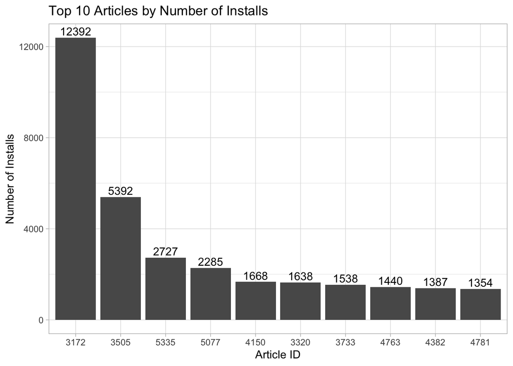

```r
# Effective Articles - App Downloads and Converted

# Cunting and selecting the number of articles in the app_install_events
# These articles drove users to install the app
Effective_Articles <- sqldf('SELECT A.article_id, COUNT(*) AS Number_of_Acquisitions
                            FROM branded_content_events AS B
                            INNER JOIN app_install_events AS A
                            ON B.uid = A.uid
                            GROUP BY article_id
                            ORDER BY Number_of_Acquisitions DESC')

Effective_Art_Visz <- ggplot(head(Effective_Articles, 10), aes(reorder(article_id, -Number_of_Acquisitions), Number_of_Acquisitions))  +
  geom_text(aes(label = round(Number_of_Acquisitions,2)), vjust = -0.3) +
  geom_bar(stat = 'identity')  +
  labs(y= 'Number of Installs',
       x= "Article ID",
       title = "Top 10 Articles by Number of Installs") +
  theme_light()
print(Effective_Art_Visz)
```

### **Most Effective Articles to Subscription**

Deeper into the funnel and taking subscription as main driver, the following articles are the ones that drove more users to install the app and convert this users into subscribed members.

These are the high quality and engaging articles that drove more users to install the app and convert into subscribed members.

I am concerned about timing of the articles and news (People don’t care about old news!), but ideally these are the articles we want to keep making ads with.

**NOTE**

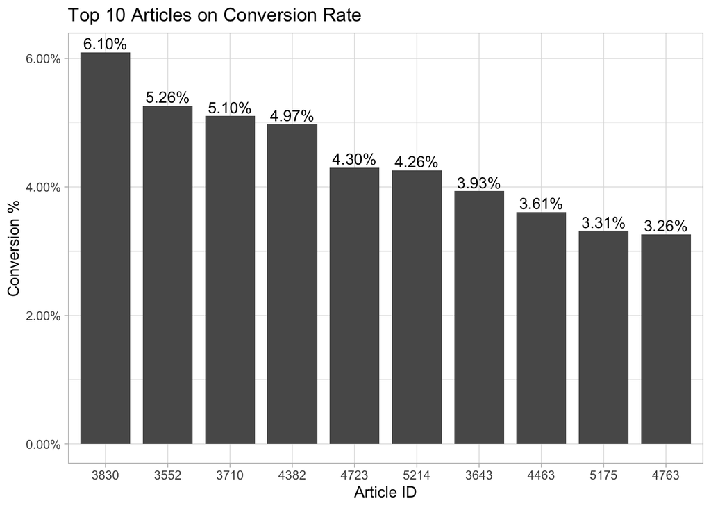

```r
# Joning app_install_events with checkout_events to detect the article in which the users were acquired.
# Filtering only for converted users
Effective_Articles_Conversion <- sqldf('SELECT A.article_id,
                            COUNT(*) AS Number_of_Acquisitions
                            FROM branded_content_events AS B
                            INNER JOIN app_install_events AS A
                            ON B.uid = A.uid
                            INNER JOIN checkout_events AS E
                            ON A.device_id = E.device_id
                            WHERE E.binary = 1
                            GROUP BY A.article_id
                            ORDER BY Number_of_Acquisitions DESC')

# Article Effectiveness Ratio to Conversion
# Calculating Article Installs and Conversions to build an effectiveness ratio
Most_Effective_Articles <- sqldf('SELECT E.article_id,
                                  C.Number_of_Acquisitions AS Conversions,
                                  E.Number_of_Acquisitions AS Installs
                                  FROM Effective_Articles as E
                                  INNER JOIN Effective_Articles_Conversion as C
                                  ON E.article_id = C.article_id
                                 ')
# Calculating the ratio of effective articles NOTE (Could not do it in SQLdf Syntax due to object type)
Articles_Ratio <-  Most_Effective_Articles %>%
  mutate(Article_Ratio_Col = Conversions/Installs) %>%
  arrange(desc(Article_Ratio_Col)) %>%
  filter(Installs > 146) # Median number of Installs

# Viusalizing the top 15 Articles by ratio
Effective_Ratio_Conv_Visz <- ggplot(head(Articles_Ratio, 10), aes(reorder(article_id, -Article_Ratio_Col), Article_Ratio_Col))  +
  geom_text(aes(label = scales::percent(Article_Ratio_Col), vjust = -0.3)) +
  geom_bar(stat = 'identity', width = 0.8)  +
  labs(y= 'Conversion %',
       x= "Article ID",
       title = "Top 10 Articles on Conversion Rate") +
  scale_y_continuous(label = scales::percent) +
  theme_light()
print(Effective_Ratio_Conv_Visz)
```

## 3.Type of Device

### **Conversions by Type of Device**

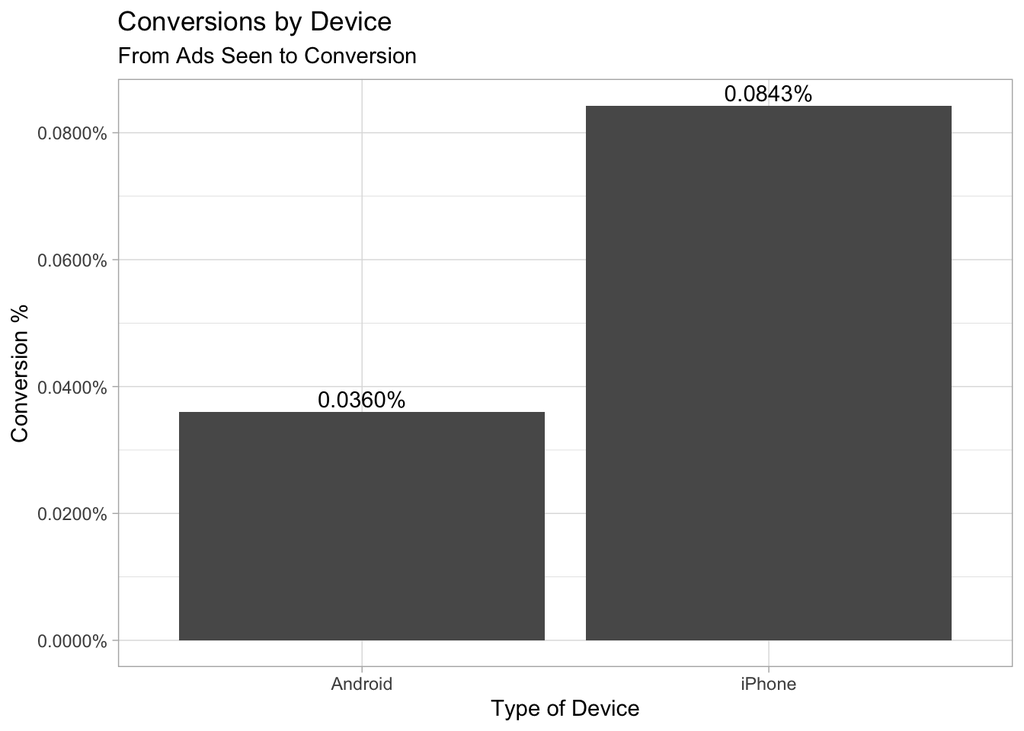

```r
# Filtering from ad seen to conversion by type of device.
Device_Effectiveness <- sqldf('SELECT platform, COUNT(platform) AS Users_Acquired
                            FROM branded_content_events AS B
                            INNER JOIN app_install_events AS A
                            ON B.uid = A.uid
                            INNER JOIN checkout_events AS E
                            ON A.device_id = E.device_id
                            WHERE E.binary = 1
                            GROUP BY platform')


# Creating a vector to divide over total number of users who saw an add
Total_Number_Users <- as.numeric(c('641754', '1382323'))

Device_Effectiveness <- Device_Effectiveness %>%
  mutate(Total = Total_Number_Users,
         Device_Ratio = (`Users_Acquired`/`Total_Number_Users`))

Device_Effectiveness_Visz <- ggplot(Device_Effectiveness, aes(platform, Device_Ratio))  +
  geom_text(aes(label = scales::percent(Device_Ratio), vjust = -0.3)) +
  geom_bar(stat = 'identity')   +
  scale_y_continuous(labels = scales::percent) +
  labs(y= 'Conversion %',
       x= "Type of Device",
       title = "Conversions by Device",
       subtitle = "From Ads Seen to Conversion") +
  theme_light()
print(Device_Effectiveness_Visz)
```

## 4.Days to Subscription

### **First Ad to Subscription Days**

Finally, low activations after day 17th of serving the first ad. Probably a good point to end retargeting campaigns for users, these seems to be user that are likely to convert. - 2 weeks after installing the app.

**NOTE**

Users who started a free trial and users that made a direct purchase were not distinguished for this portion of the analysis.

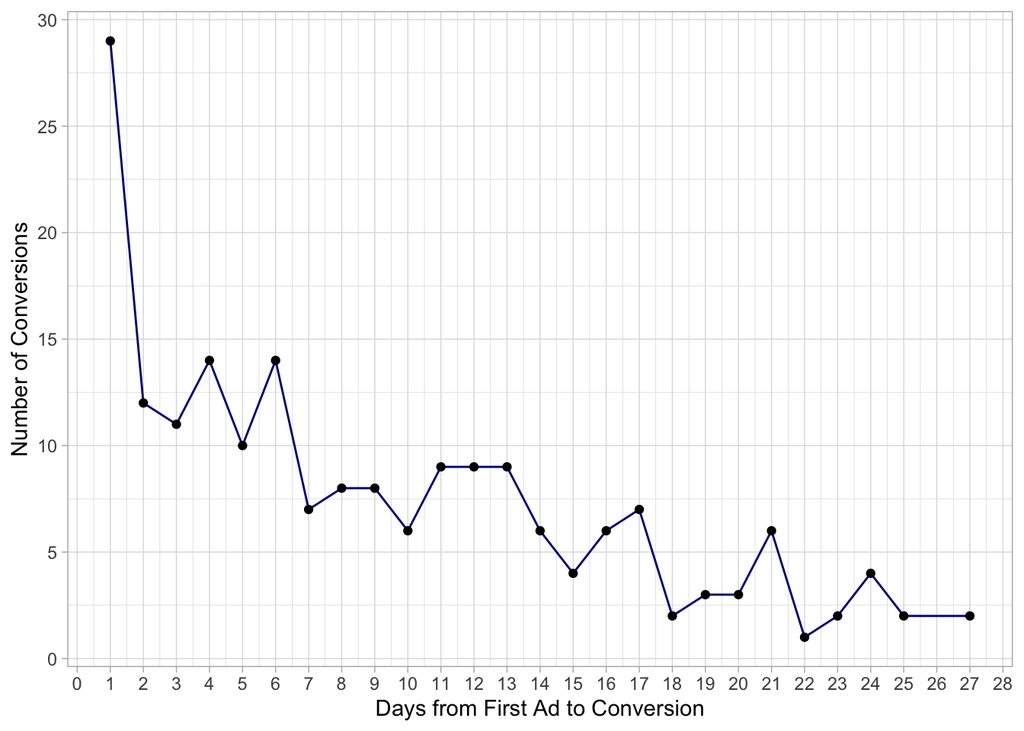

```r
# First Ad Seen to Checkout - Converted users

First_Ad_to_Checkout <- sqldf('SELECT E.device_id,
                            MIN(B.event_time) AS First_Ad_Seen,
                            E.checkout_time,
                            E.binary
                            FROM branded_content_events AS B
                            INNER JOIN app_install_events AS A
                            ON B.uid = A.uid
                            INNER JOIN checkout_events AS E
                            ON A.device_id = E.device_id
                            WHERE E.binary = 1
                            GROUP BY E.device_id
                            ')

# Processing Date for First_Ad_to_Checkout
First_Ad_to_Checkout$First_Ad_Seen <- as.POSIXct(First_Ad_to_Checkout$First_Ad_Seen, origin = '1970-01-01') # Converting from epoch time to POSIXct and displaying number of days only.
First_Ad_to_Checkout$FirstAd_to_Conversion <- round(as.numeric(difftime(First_Ad_to_Checkout$checkout_time,
                                                                         First_Ad_to_Checkout$First_Ad_Seen,
                                                                         units = 'days')))

Conversion_Days_Diff <- First_Ad_to_Checkout %>%
  group_by(FirstAd_to_Conversion) %>%
  summarise('Number_of_Downloads' = sum(binary)) %>%
  arrange(desc(-FirstAd_to_Conversion)) %>%
  mutate(cumsum = cumsum(Number_of_Downloads)) %>%
  filter(FirstAd_to_Conversion >= 1)

# Adding the total number of users acquired from the previous day.
Conversion_Days_Diff$sum <- cumsum(Conversion_Days_Diff[, 2])

# Calculating percentage of users acquired
Conversion_Days_Diff$users_perc <- round((Conversion_Days_Diff[,3]/1006)*100,2)

# Visualize this on a trend line!
Conversion_Days_Visz <- ggplot(data=Conversion_Days_Diff, aes(x=FirstAd_to_Conversion, y=Number_of_Downloads)) +
  geom_line(colour='darkblue') +
  geom_point() +
  scale_y_continuous(breaks = seq(from=0, to=40, by=5)) + # Changing the Monthly_Revenue variable to Dollars
  scale_x_continuous(breaks=seq(from=0, to=30, by=1))  +
  labs(y='Number of Conversions',
       x='Days from First Ad to Conversion') + # Chanign y-axis name
  theme_light()
print(Conversion_Days_Visz)
```

## 5.Decision Tree Model

### **Data Preparation**

A tree based model has been constructed to identify the main driver for users subscription. The following variables were constructed and used for the model:

- Number of distinct camapaigns seen on FB
- Device used by the User (Android or iPhone)
- Source (Ad or Organic)
- Days from First Ad seen to Conversion

A total of 2,447 observations of users were traceable from the moment of the FB first ad seen to the point of checkout.

```r
# Simple Tree Based Model
# Selecting and constructing the first variables to fit a tree model
# Number of distinct campaigns seen by user
# Source
# Platform
Model <- sqldf('SELECT B.uid,
                COUNT(DISTINCT(B.campaign_name)) AS Number_of_Campaigns_Seen,
                MIN(B.event_time) AS First_Ad_Seen,
                B.platform,
                A.event_time AS Time_of_Install,
                A.source,
                A.device_id
                FROM branded_content_events AS B
                INNER JOIN app_install_events AS A
                ON B.uid = A.uid
                GROUP BY A.uid
                            ')

# Final Join with Checkout Time to construct andf build model

Model_2 <- sqldf('SELECT M.uid,
                M.Number_of_Campaigns_Seen,
                 M.First_Ad_Seen,
                 M.platform,
                 M.Time_of_Install,
                 M.source,
                 M.device_id,
                 C.checkout_time,
                 C.binary
                 FROM Model AS M
                 INNER JOIN checkout_events AS C
                 ON M.device_id = C.device_id
                 GROUP BY M.uid
                 ')


# Processing Dates again as they were lost with SQLdf!

# Modifying Dates and Calculting Days in days
Model_2$First_Ad_Seen <- as.POSIXct(Model_2$First_Ad_Seen, origin = "1970-01-01")
Model_2$Time_of_Install <- as.POSIXct(Model_2$Time_of_Install, origin = "1970-01-01")

# Days First Day ad Seen to Time of Install
Model_2$FirstAd_to_Install_Days<- round(as.numeric(difftime(Model_2$Time_of_Install,
                                                            Model_2$First_Ad_Seen,
                                                            units = 'days')))

# Days First Day ad Seen to Time of Conversion
Model_2$FirstAd_to_Conversion_Days<- round(as.numeric(difftime(Model_2$checkout_time,
                                                            Model_2$First_Ad_Seen,
                                                            units = 'days')))

# Selecting relevant variables for the Tree Based Model

Model_Table <- Model_2 %>%
  select(-First_Ad_Seen, -Time_of_Install, -device_id, -checkout_time, -FirstAd_to_Install_Days)



# Showing the first 20 observations of the dataset
DT::datatable(head(Model_Table, 20),
              rownames = FALSE,
              options = list(
                pageLength = 5))
```

| uid | Number_of_Campaigns_Seen | platform | source | binary | FirstAd_to_Conversion_Days |
| --- | --- | --- | --- | --- | --- |
| 000e2c | 1 | iPhone | facebook_ads | 0 | 0 |
| 0013fb | 1 | iPhone | facebook_ads | 0 | 0 |
| 00172d | 1 | iPhone | facebook_ads | 0 | 0 |
| 001c64 | 1 | iPhone | facebook_ads | 0 | 0 |
| 00215f | 1 | iPhone | facebook_ads | 0 | 0 |
| 00222f | 1 | Android | facebook_ads | 1 | 0 |
| 002518 | 1 | iPhone | facebook_ads | 0 | 0 |
| 002681 | 1 | iPhone | facebook_ads | 0 | 0 |
| 00271e | 2 | iPhone | facebook_ads | 0 | 10 |
| 002cf9 | 1 | iPhone | facebook_ads | 1 | 0 |

[output cut: 10 more lines]

### **Building a Decision Tree Model**

For the decision tree model two libraries were used:

- rpart to fit the model
- rpart.plot to visualize the results and clearly show them to an audience.

To undestand the tree, read statement and move right if answer to the statement is ‘no’, move left if answer is ‘yes’.

Numbers below each bubble represent the number of users subscribed (right), number of users not subscribed (left).

```r
Model_Final<- Model_2 %>%
  select(-First_Ad_Seen, -Time_of_Install, -device_id, -checkout_time, -FirstAd_to_Install_Days, -uid)

#### Tree Based Model ####
library(rpart)
library(rpart.plot)

set.seed(415)
#Building the pediction tree # Using all the variables
Model_tree <- rpart(binary ~ .,
                    data=Model_Final, method="class",control= rpart.control(cp=0.003))
```

### **Decision Tree Model Graph**

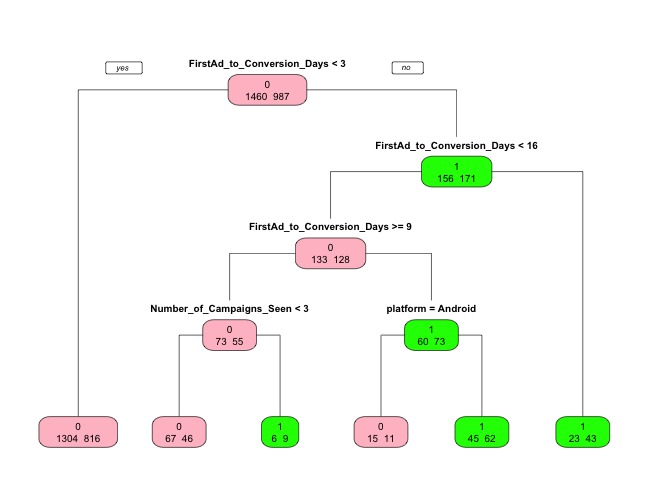

Luis Noguera

### **Model Summary Insights**

- iPhone users with less than 9 days after seeing the first ad in FB are 15% more likely to convert than those with an Android device.
- Users between 9-16 days of seeing the first ad and with more than 3 campaigns seen are 20% more likely to convert than users between that time frame and less number of campaigns served. (This makes sense, users do not want the same ad/article to be served multiple times!)
- Users with less than 3 days of seeing the first ad and downloading the app less likely to convert. (Hmm! Users are really looking forward to that 7 day trial)
- App users with more than 16 days of seeing the first ad are likely to convert, regardelss of number of campaigns seen or device used.

## 6. Summary and Recommendations

### **Team Recommendations**

**Performance Team**

**Product Team**

### **Model Summary Insights**

- iPhone users with less than 9 days after seeing the first ad in FB are 15% more likely to convert than those with an Android device.
- Users between 9-16 days of seeing the first ad and with more than 3 campaigns seen are 20% more likely to convert than users between that time frame and less number of campaigns served. (This makes sense, users do not want the same ad/article to be served multiple times!)
- Users with less than 3 days of seeing the first ad and downloading the app less likely to convert. (Hmm! Users are really looking forward to that 7 day trial)
- App users with more than 16 days of seeing the first ad are likely to convert, regardelss of number of campaigns seen or device used.

### **Further Analysis**

**Campaign Cost Data**

Cost metrics would make this analysis more complete, adding a layer of budget optimazation for the performance team.

This would allow to understand Return On Ad Spend and optimize the money returned by each FB campaign.

**User Behavior Data**

To better understand where Android users are converting less. User behavior data would help the product team to optimize for important drops on user pages and tweak tests to improve.